# Covid and Covid Related Fatalities

Ben Beck

2025-06-05

# Sex, Location, Time, Temperature: Greatest Impacts on Covid Fatalities

### Introduction

The COVID-19 pandemic has profoundly impacted global health, with varying mortality rates influenced by demographic, geographic, and environmental factors. This study aims to elucidate the relationships between COVID-19 fatalities and variables such as sex, location, time, and temperature across the United States. By integrating mortality data with demographic statistics and environmental information, the research seeks to identify patterns and correlations that may inform public health strategies and interventions.

Utilizing data from the Centers for Disease Control and Prevention (CDC) and state-level temperature records, the study employs statistical analyses to explore how these factors interact and contribute to the observed mortality trends. The findings are intended to provide insights into the multifaceted nature of the pandemic’s impact and to support data-driven decision-making in public health policy.

### • Set-Up

#### Dependencies

#### Cleaning Data

#### Preparation

## • Monthly Trends in COVID-19 and Related Deaths in the U.S

This analysis explores trends in monthly mortality related to COVID-19, pneumonia, and cases involving both conditions across the United States. By grouping and visualizing death counts by month and year, the aim to identify patterns or spikes in mortality that may be associated with seasonal factors or the progression of the pandemic. Additionally, a statistical test (ANOVA) is conducted to determine whether there are significant differences in COVID-19-related death counts across different months. This helps assess whether time of year meaningfully influences mortality rates or if observed variations are likely due to chance.

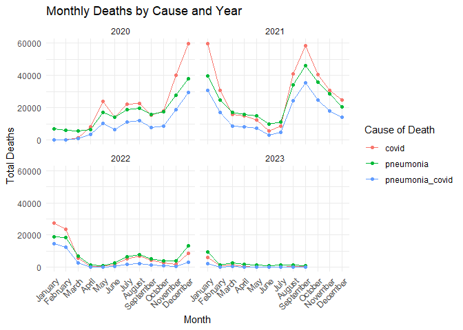

Just after looking at the graph, there doesn’t appear to be a strong correlation. However, we do notice that there appears to be more deaths around the winter months (December and January). Still, a statistical test is needed to explore how much of an effect it has.

#### Anova Summary Result

```
##             Df    Sum Sq   Mean Sq F value Pr(>F)
## month       11 2.784e+09 253090099   0.837  0.606
## Residuals   33 9.975e+09 302265993
```

The ANOVA analysis conducted on the total deaths across different months indicates that there is no statistically significant difference in the mean death counts between months. The F-statistic of 0.837, along with a p-value of 0.606, suggests that the variation observed in death counts between months is likely due to random chance rather than a systematic effect of the month itself. Since the p-value is greater than the typical significance threshold of 0.05, we fail to reject the null hypothesis, which posits that the mean deaths across the months are equal. In practical terms, this means that, based on the available data, there is no strong evidence to suggest that the month of the year has a significant impact on the number of deaths. The observed differences in death counts from one month to another could be attributed to random variation rather than seasonal or other temporal effects. Further investigations, possibly incorporating other variables such as regional factors, underlying health conditions, or external events, may be needed to better understand the patterns in mortality over time.

## • Temperature Influences on Covid-19 and Related Deaths

This analysis explores whether there is a relationship between ambient temperature and Covid-19 and related deaths across the US. To visualize this potential association, below is a scatter plot of total deaths against temperature, along with a fitted linear regression line.The Pearson correlation coefficient was tested to quantify the strength and direction of the relationship and a correlation test to determine statistical significance.

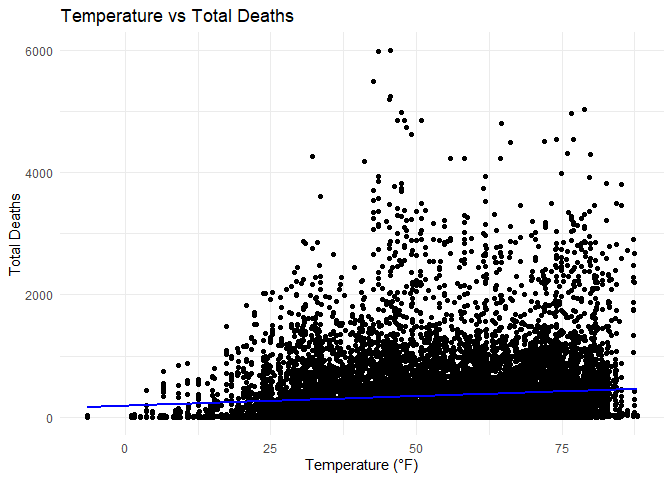

From looking at the graphs, temperature does NOT appear to have a significant effect on the death rate of Covid-19 or related diseases. More statistical tests, though, will be done to find out if there is any kind of correlation.

##### Correlation

```
## [1] 0.1003227
```

##### Correlation Test

```
## [1] 2.048246e-36
```

The analysis of the relationship between temperature and total deaths indicates a very weak positive correlation, with a Pearson correlation coefficient of 0.1003. This suggests that while there is a slight tendency for total deaths to increase as temperature rises, the relationship is not strong. However, the correlation is statistically significant, as evidenced by the extremely small p-value of 2.048246e-36, which indicates that the correlation is unlikely to be due to random chance. Despite the statistical significance, the weak strength of the correlation suggests that temperature is not a strong predictor of total deaths.

#### How Temperature’s Effect Changes Year to Year

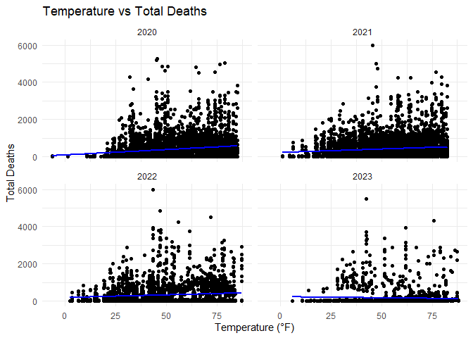

From the appearance of the plots, it looks as though there is a correlation between increasing temperatures and increased deaths in the total deaths from Covid-19 and related diseases. Some statistical tests will be done to determine if it is significant, and how much of an influence temperature has on the data.

##### P-Values Year to Year

```
## # A tibble: 4 × 2
## # Groups:   year [4]
##    year  p_value
##   <dbl>    <dbl>
## 1  2020 4.56e-29
## 2  2021 2.90e-20
## 3  2022 8.51e- 8
## 4  2023 3.32e- 2
```

##### R-Squared

```
## # A tibble: 4 × 2
##    year r_squared
##   <dbl>     <dbl>
## 1  2020   0.0276
## 2  2021   0.0145
## 3  2022   0.00908
## 4  2023   0.00202
```

The relationship between temperature and total deaths was analyzed for each year from 2020 to 2023. The results show that while the correlation is statistically significant in all years (p-values < 0.05), the strength of the relationship is extremely weak, as indicated by the low R-Squared Values.

These findings suggest that although temperature appears to have a statistically significant effect on total deaths, it explains less than 3% of the variation in deaths in any year. Therefore, temperature is not a strong predictor of total mortality and likely interacts with many other more influential factors.

### How Temperature’s Effect Changes Based on Month

Below is a scatter plot of Covid-19 and Related deaths vs temperature from month to month.

[figure not shown]

##### Linear Regression Test

```
##
## Call:
## lm(formula = covid_deaths ~ temperature, data = dat)
##
## Residuals:
##     Min      1Q  Median      3Q     Max
##  -43.50  -42.53  -28.48    7.65 2285.29
##
## Coefficients:
##             Estimate Std. Error t value Pr(>|t|)
## (Intercept) 43.40652    2.24356  19.347   <2e-16 ***
## temperature -0.01537    0.03936  -0.391    0.696
## ---
## Signif. codes:  0 '***' 0.001 '**' 0.01 '*' 0.05 '.' 0.1 ' ' 1
##
## Residual standard error: 87.97 on 15701 degrees of freedom
## Multiple R-squared:  9.716e-06,  Adjusted R-squared:  -5.397e-05
## F-statistic: 0.1526 on 1 and 15701 DF,  p-value: 0.6961
```

##### Anova Test

```
##                Df    Sum Sq Mean Sq F value Pr(>F)
## month          11   4800641  436422   60.13 <2e-16 ***
## temperature     1   2839881 2839881  391.29 <2e-16 ***
## Residuals   15690 113875120    7258
## ---
## Signif. codes:  0 '***' 0.001 '**' 0.01 '*' 0.05 '.' 0.1 ' ' 1
```

## • State Influences on Covid-19 and Related Deaths

Below is a graph of the total deaths across states, thoughout time.

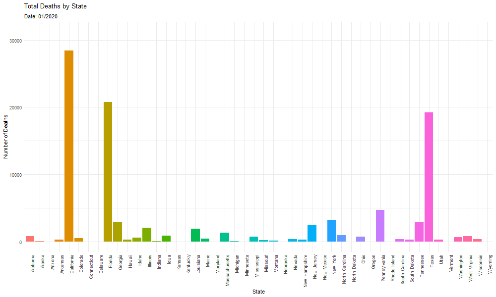

Total Deaths by State

Below is a similar graph of the total deaths per population across the states, throughout time

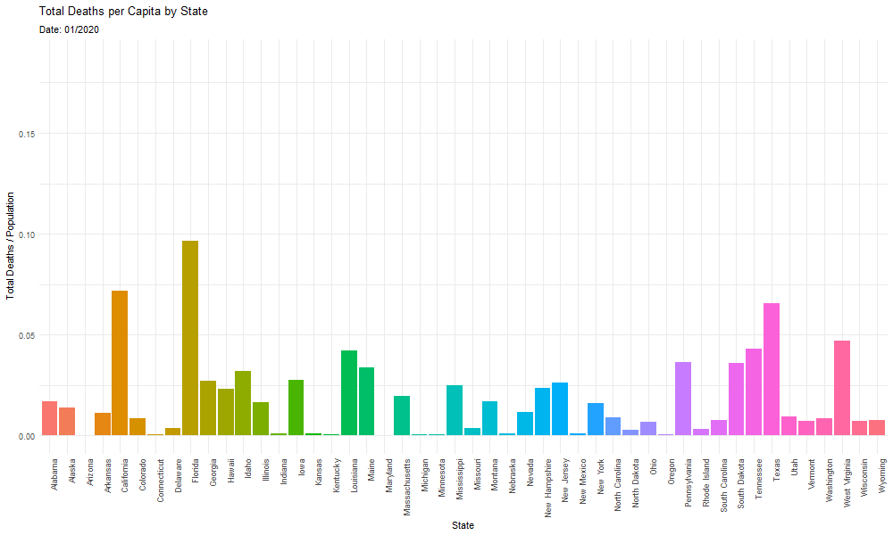

Here is the same graph with averages across each year:

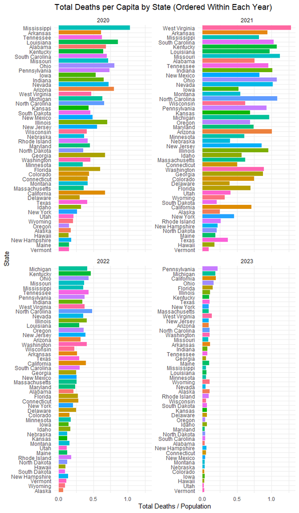

##### Anova Test on States vs Total Deaths

```
##                Df    Sum Sq Mean Sq F value Pr(>F)
## state          47  16823517  357947   53.52 <2e-16 ***
## Residuals   15655 104692124    6687
## ---
## Signif. codes:  0 '***' 0.001 '**' 0.01 '*' 0.05 '.' 0.1 ' ' 1
```

The ANOVA test results show a statistically significant relationship between the state and COVID-19 deaths (F(47, 15655) = 53.52, p < 2e-16). This indicates that the average number of COVID-19 deaths differs significantly across states. The extremely small p-value suggests that these variations are highly unlikely to be due to chance, supporting the conclusion that state-specific factors likely contribute to differences in COVID-19 death rates.

##### Random Forest Model for Predicting COVID-19 Deaths

In this section is a Random Forest model to predict COVID-19 deaths based on multiple factors, including temperature, state, sex, and age group. The Random Forest algorithm, an ensemble learning method, is well-suited for this task due to its ability to handle complex datasets and model nonlinear relationships between variables.

###### Mean Squared Error (MSE)

```
## [1] "Mean Squared Error (MSE): 5295.87219670788"
```

###### Visualize feature importance

```
##             IncNodePurity
## temperature       8160732
## state             5331077
## sex                477796
## age_group        13137925
```

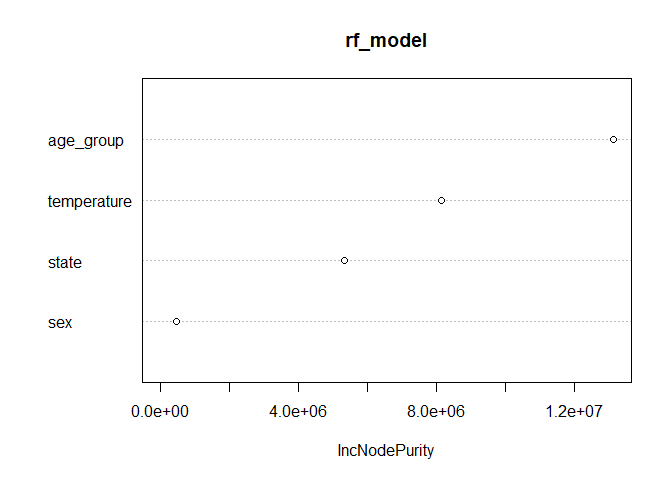

## • Age Group’s Effect on Covid-19 and Related Deaths

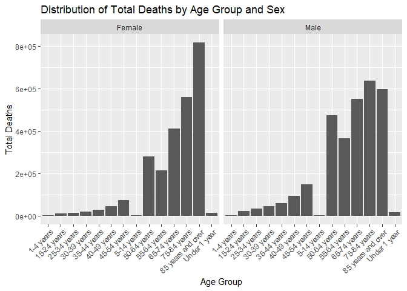

This graph shows the total deaths by age group, separated by sex. It allows for a comparison of how deaths are distributed across different age groups for males and females.

[figure not shown]

##### Statistical Analysis of Deaths Across Age Groups

```
##                  Df    Sum Sq   Mean Sq F value  Pr(>F)
## sex               1 3.248e+06   3247958   18.52 1.7e-05 ***
## age_group        13 2.000e+09 153860979  877.07 < 2e-16 ***
## sex:age_group    13 9.254e+07   7118585   40.58 < 2e-16 ***
## Residuals     15675 2.750e+09    175427
## ---
## Signif. codes:  0 '***' 0.001 '**' 0.01 '*' 0.05 '.' 0.1 ' ' 1
```

The results of the ANOVA indicate significant effects for sex, age group, and their interaction on the dependent variable. The sex variable showed a significant effect (F = 18.52, p < 0.001), as did age group (F = 877.07, p < 2e-16), with both factors contributing notably to the variation in the data. Additionally, the interaction between sex and age group was highly significant (F = 40.58, p < 2e-16), suggesting that the relationship between the dependent variable and age group differs depending on sex. The residuals indicate that there is still some unexplained variation in the model, but the significant p-values for the factors and their interaction suggest a strong model fit.

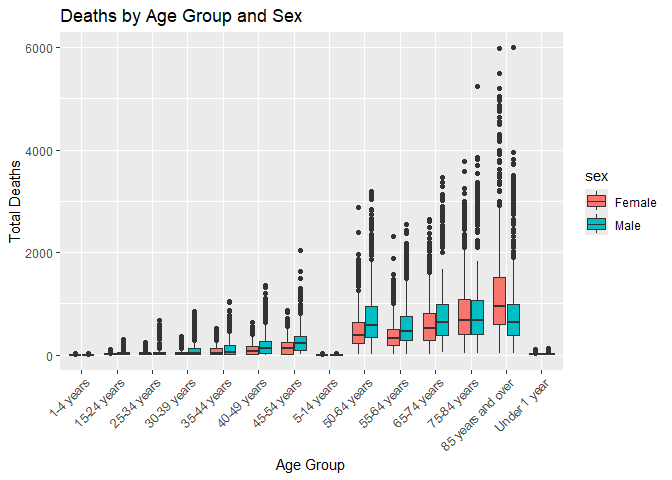

## • References

https://catalog.data.gov/dataset/provisional-covid-19-death-counts-by-sex-age-and-state

https://www.ncei.noaa.gov/access/monitoring/climate-at-a-glance/statewide/time-series/48/tavg/1/0/2020-2023

https://www.census.gov/data/tables/time-series/demo/popest/2020s-state-total.html